# Executive Summary

Final Project  
Data Science 1 with R (STAT 301-1)

Author

Caroline Corr

Published

December 10, 2024

# Societal Biases in Survivor

##### Link to GitHub Repository

**Note**

[Caroline Corr’s Final Project Repo](https://github.com/stat301-1-2024-fall/final-project-1-carolinecorr)

## Overview

CBS’ Survivor is considered by many to be television’s greatest social experiment. In order to be a true social experiment, it should accurately reflect the diversity of the society that it attempts to mirror. Similarly, as a game played between individuals all with $1,000,000 in mind, the same biases that influence society would surely influence the game all the same.

In order to gauge how societal biases function in the game of Survivor, I have tracked two major domains of bias: the casting level and the interpersonal level. Through explorations involving demographic factors such as age, race/ethnicity, gender, and sexuality, I have uncovered sources of bias in both domains.

[Link to Dataset](https://www.kaggle.com/datasets/justinveiner/survivor-cbs-dataset)

# Findings and Conclusions

On the casting level, it appears that the greatest sources of bias are age and ethnicity, for older generations and Latin Americans are the most underrepresented demographics on the show according to U.S. Census information.

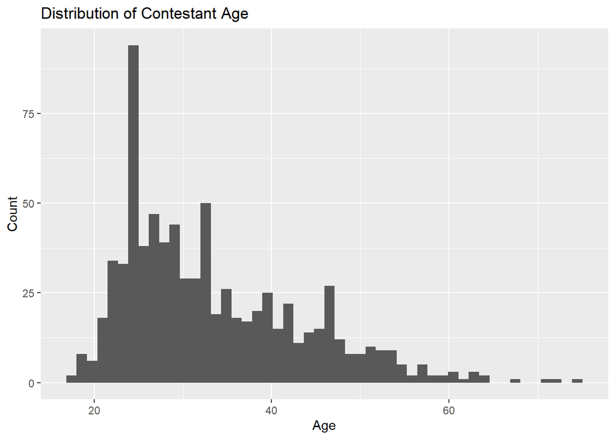

Figure 1

Table 1: Ethnic Composition of Survivor Contestants Compared to National Composition

| Ethnicity | N | Survivor % | National % | Difference |
| --- | --- | --- | --- | --- |
| African American | 114 | 14.52 | 13.7 | 0.82 |
| Asian American | 61 | 7.77 | 6.4 | 1.37 |
| Caucasian | 554 | 70.57 | 58.4 | 12.17 |
| Latin American | 56 | 7.13 | 19.5 | -12.37 |

While the lack of representation of older people could be attributed to the fact that Survivor is an intensely physical and uncomfortable experience not entirely suitable for senior members of society, the underrepresentation of Latin American people has no such justification.

On the interpersonal level, while biases do exist against certain age groups, races, and sexual identities, the most overwhelming source of bias appears to be gender.

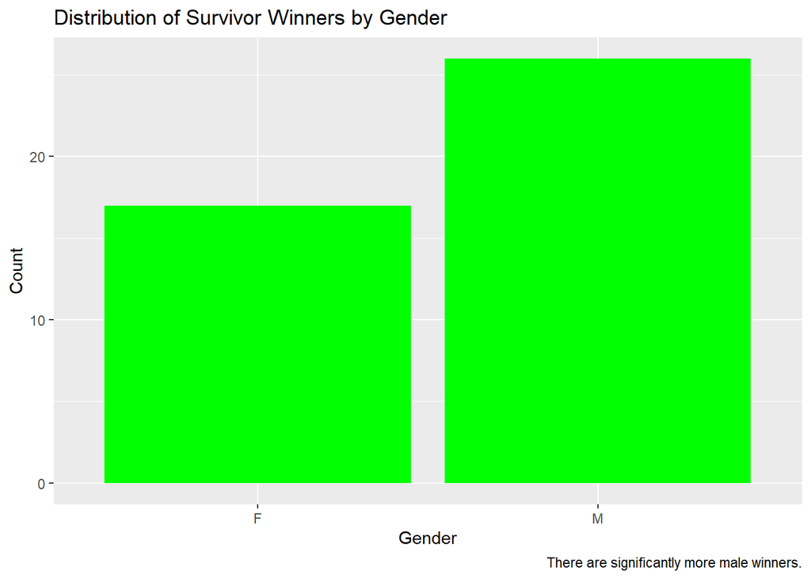

Figure 2

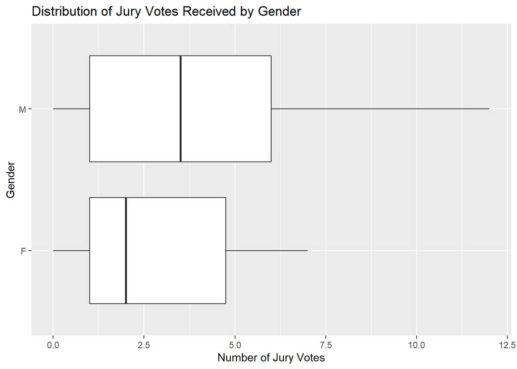

Figure 3

Not only have considerably more men won the show than women, but male finalists tend to receive more jury votes, and male winners tend to win by higher margins.

This is an interesting finding, for there is no bias against female contestants on the production level due to the equal representation of men and women across every season of the show. This bias emerges only on the level of game play, so it is inflicted upon female players purely by their fellow contestants and the perceptions they carry concerning a woman’s physical capabilities and overall disposition.